# Logistic Regression

Zhaoxia Yu

## Load packages, read data

```r
library(fabricerin)
library(tidyverse)
library(ggplot2)
```

```r
library(fabricerin)
library(tidyverse)
library(ggplot2)

#read, select variables
#remove impaired, and define new variables
alzheimer_data <- read.csv('../data/alzheimer_data.csv') %>%
  select(id, diagnosis, age, educ, female, height, weight, lhippo, rhippo) %>%
  filter(diagnosis!=1) %>%
  mutate(alzh=(diagnosis>0)*1, female = as.factor(female), hippo=lhippo+rhippo)

table(alzheimer_data$alzh)
```

```
   0    1
1534  553
```

```r
ggplot(data=alzheimer_data, aes(x=alzh)) +
  geom_bar()
```

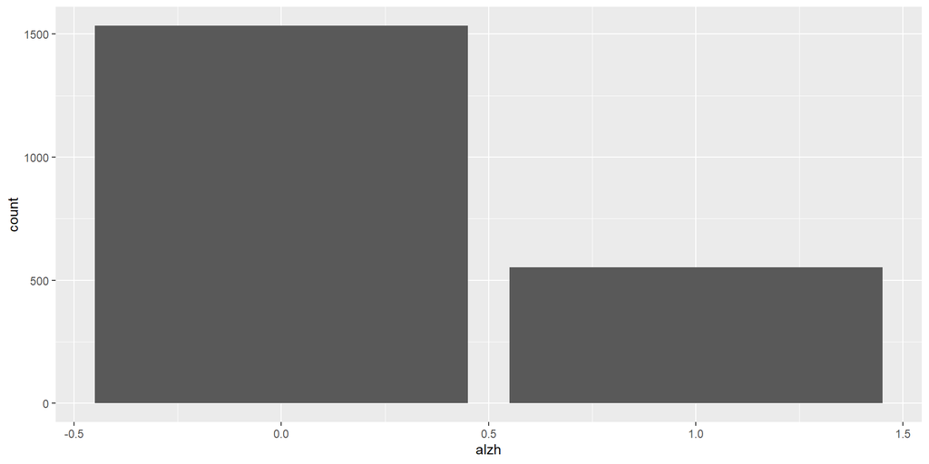

### Outline

- Introduction
  - Motivating example: alzh ~ hippo
- Ex1: One binary predictor
- Ex2: One numerical predictor
- Ex3: Multiple predictors
- Additional examples
  - Ex4: one numerical predictor
  - Ex5: mulitple predictors

## Introduction

### Motivating example: alzh ~ hippo

```r
ggplot(data=alzheimer_data, aes(x=hippo, y=alzh)) +
  geom_point() +
  geom_smooth(method='lm', se=FALSE) +
  labs(title="alzh vs hippo")
```

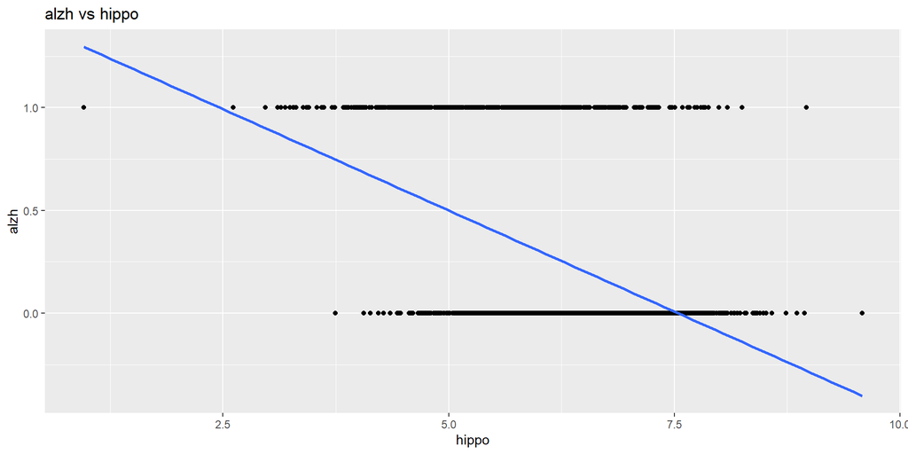

- Any comments about the linear fit?

### Predict Binary Responses (wrong way)

- Now let us do predictions using linear regression: `alzh.lm`

```r
alzh.lm=lm(alzh ~ hippo, data=alzheimer_data)
#add lm.pred variable
alzheimer_data$lm.pred=predict(alzh.lm)
#add red flags
alzheimer_data$lm.pred.red = alzheimer_data$lm.pred
alzheimer_data$lm.pred.red[alzheimer_data$lm.pred<1 &
                             alzheimer_data$lm.pred>0]=NA
ggplot(alzheimer_data) +
  geom_point(aes(x=alzh, y=lm.pred)) +
  geom_point(aes(x=alzh, y=lm.pred.red), col="red") +
  geom_hline(yintercept = c(0,1), col='red') +
  labs(x="true alzh", y="predicted by lm")
```

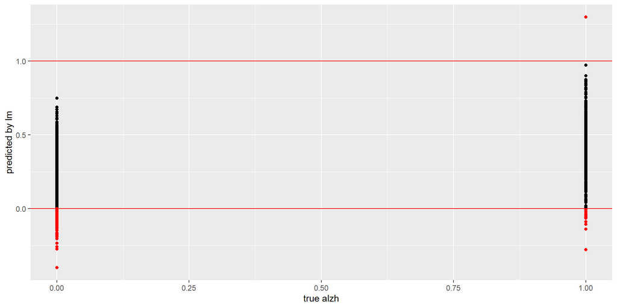

- Is `alzh.lm` a good model?

### Binary Response Variables

- Recall that `alzh` is a binary variable.
- We tried linear regression: `alzh` $\sim$ `hippo`
  - It does not fit well: the difference between fitted and observed is large for most data points.
  - The predicted/ values for the binary response variable `alzh` can be greater than 1 or less than 0.

### Binary Response Variables

- Now consider situations where the response variable $Y$ is a binary random variable (e.g., disease status).
- Recall that a Bernoulli distribution can be used to characterize the behavior of a binary random variable.

$$Y \sim Bernoulli(p),$$

where, $p$ is the probability of the outcome of interest (denoted as 1) given the explanatory variables.

### Odds

- In statistics, odds quantifies of the relative probabilities of an event and its complement

$$odds=\frac{P(A)}{P(A^c)}=\frac{P(A)}{1-P(A)}.$$

- For a binary variable $Y$. Assume $Y\sim Bernoulli(p)$. The odds is

$$odds = \frac{P(Y=1)}{P(Y=0)}=\frac{p}{1-p}$$

- The range of odds is $[0,\infty)$. Can you find a transformation such as that the range is $(-\infty, \infty)$?

### Log-Odds and Logit Transformation

- $log \left( \frac{p}{1-p}\right)$ is called the **logit** function, i.e.,

$$logit(p)=log \left( \frac{p}{1-p}\right).$$

```r
p=seq(0.01, 0.99, 0.01)
logit.p=log(p/(1-p))
plot(p, logit.p, type="l", xlab=expression(pi), main="the logit function")
```

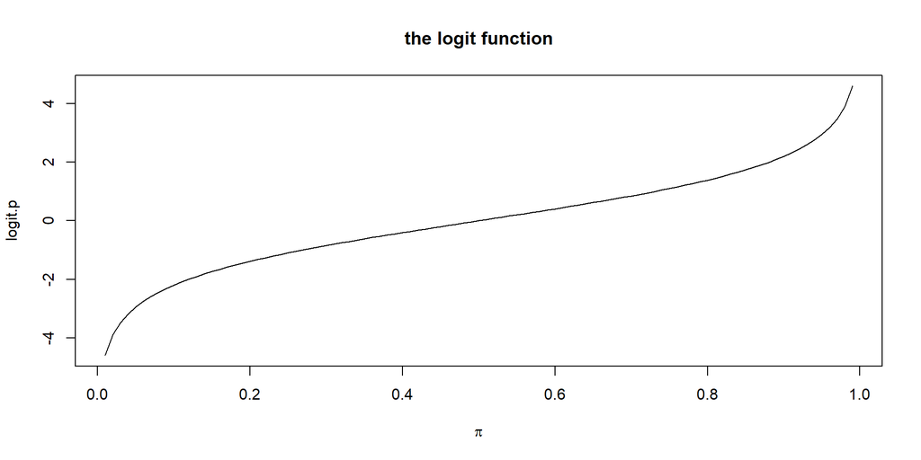

### How to Model Binary Responses?

- Linear regression is not good choice for a binary response variable.
- For linear regression models, the response variable, $Y$, is assumed to be a real-valued continuous random variable.
- When the response variable is binary, such as `alzh`, how should we model it using one or multiple covarites?
- For such problems, it is common to use **logistic regression** instead

### Logisitc Regression

- In a logistic regression, we model the *log odds* using a linear combination of the explantoary variables (predictors):

$$\begin{align*}
\log \left(\frac{\hat{p}}{1- \hat{p}} \right) & = b_{0} + b_{1}x_1 + \ldots + b_{q}x_{q}
\end{align*}$$

- The term $\Big(\frac{\hat{p}}{1- \hat{p}} \Big)$ is called the **odds** of $Y=1$.
- The term $\log \Big(\frac{\hat{p}}{1- \hat{p}} \Big)$, i.e., log of odds, is called the **logit** function.
- Although $p$ is a real number between 0 and 1, its logit transformation can be any real number between $-\infty$ to $+\infty$.

## Ex1: One Binary Predictor

### Birthweight data

- As an example, we use the `birthwt` data set to model the relationship between having low birthweight babies (a binary variable), $Y$, and smoking during pregnancy, $X$.
- The binary variable `low` identifies low birthweight babies (low = 1 for low birthweight babies, and 0 otherwise).
- The binary variable `smoke` identifies mothers who were smoking during pregnancy (smoke=1 for smoking during pregnancy, and 0 otherwise).

### Birthweight data

```r
library(MASS)
data(birthwt)
table(birthwt$low, birthwt$smoke)
```

```
     0  1
  0 86 44
  1 29 30
```

- `chisq.test` can be used for testing the associaiton between them.
- A logistic regression provides more information

### Logistic Regression with One Binary Predictor: Generalized linear model (glm) in R

- We can use the `glm()` function in R to fit a regression model

```r
birthwt <- birthwt %>%
  mutate(across(c(low, smoke, race, ht, ui), factor))
glimpse(birthwt)
```

```
Rows: 189
Columns: 10
$ low   <fct> 0, 0, 0, 0, 0, 0, 0, 0, 0, 0, 0, 0, 0, 0, 0, 0, 0, 0, 0, 0, 0, 0…
$ age   <int> 19, 33, 20, 21, 18, 21, 22, 17, 29, 26, 19, 19, 22, 30, 18, 18, …
$ lwt   <int> 182, 155, 105, 108, 107, 124, 118, 103, 123, 113, 95, 150, 95, 1…
$ race  <fct> 2, 3, 1, 1, 1, 3, 1, 3, 1, 1, 3, 3, 3, 3, 1, 1, 2, 1, 3, 1, 3, 1…
$ smoke <fct> 0, 0, 1, 1, 1, 0, 0, 0, 1, 1, 0, 0, 0, 0, 1, 1, 0, 1, 0, 1, 0, 0…
$ ptl   <int> 0, 0, 0, 0, 0, 0, 0, 0, 0, 0, 0, 0, 0, 1, 0, 0, 0, 0, 0, 0, 0, 0…
$ ht    <fct> 0, 0, 0, 0, 0, 0, 0, 0, 0, 0, 0, 0, 1, 0, 0, 0, 0, 0, 0, 0, 0, 0…
$ ui    <fct> 1, 0, 0, 1, 1, 0, 0, 0, 0, 0, 0, 0, 0, 1, 0, 0, 0, 0, 1, 0, 0, 1…
$ ftv   <int> 0, 3, 1, 2, 0, 0, 1, 1, 1, 0, 0, 1, 0, 2, 0, 0, 0, 3, 0, 1, 2, 3…
$ bwt   <int> 2523, 2551, 2557, 2594, 2600, 2622, 2637, 2637, 2663, 2665, 2722…
```

### Generalized linear model (glm) in R

```r
fit <- glm(low ~ smoke, family = 'binomial', data = birthwt)
fit
```

```
Call:  glm(formula = low ~ smoke, family = "binomial", data = birthwt)

Coefficients:
(Intercept)       smoke1
    -1.0871       0.7041

Degrees of Freedom: 188 Total (i.e. Null);  187 Residual
Null Deviance:      234.7
Residual Deviance: 229.8    AIC: 233.8
```

### Generalized linear model (glm) in R

- We can use the `glm()` function in R to fit a regression model

```r
confint(fit)
```

```
                 2.5 %    97.5 %
(Intercept) -1.5243118 -0.679205
smoke1       0.0786932  1.335154
```

### Generalized linear model (glm) in R

- We can use the `glm()` function in R to fit a regression model

```r
summary(fit)
```

```
Call:
glm(formula = low ~ smoke, family = "binomial", data = birthwt)

Deviance Residuals:
    Min       1Q   Median       3Q      Max
-1.0197  -0.7623  -0.7623   1.3438   1.6599

Coefficients:
            Estimate Std. Error z value Pr(>|z|)
(Intercept)  -1.0871     0.2147  -5.062 4.14e-07 ***
smoke1        0.7041     0.3196   2.203   0.0276 *
---
Signif. codes:  0 '***' 0.001 '**' 0.01 '*' 0.05 '.' 0.1 ' ' 1

(Dispersion parameter for binomial family taken to be 1)

    Null deviance: 234.67  on 188  degrees of freedom
Residual deviance: 229.80  on 187  degrees of freedom
AIC: 233.8

Number of Fisher Scoring iterations: 4
```

### Estimation

- For the above example, the estimated values of the intercept $\alpha$ and the regression coefficient $\beta$ are $b_0=-1.09$ and $b_1=0.70$ respectively.
- Therefore,

$$\begin{align*}
\frac{\hat{p}}{1- \hat{p}} & = & \exp(-1.09 + 0.70x)
\end{align*}$$

- Here, $\hat{p}$ is the estimated probability of having a low birthweight baby for a given $x$.
- The left-hand side of the above equation is the estimated odds of having a low birthweight baby.

### Estimation

- For non-smoking mother, $x=0$, the odds of having low birthweight baby is
  $$\begin{align*}
  \frac{\hat{p}_{0}}{1- \hat{p}_{0}} & = & \exp(-1.09) \\
  & = & 0.34
  \end{align*}$$
- That is, the exponential of the intercept is the odds when $x=0$, which is sometimes referred to as the **baseline odds**.

### Estimation

- For mothers who smoke during pregnancy, $x=1$, and
  $$\begin{align*}
  \frac{\hat{p}_{1}}{1- \hat{p}_{1}} & = & \exp(-1.09 + 0.7)\\
  & = & \exp(-1.09) \exp(0.7)\\
  & = & 0.68
  \end{align*}$$
- As we can see, corresponding to one unit increase in $x$ from $x=0$ (non-smoking) to $x=1$ (smoking), the odds multiplicatively increases by the exponential of the regression coefficient.

### Interpretation

- Note that

$$\begin{align*}
\frac{\frac{\hat{p}_{1}}{1- \hat{p}_{1}}}{\frac{\hat{p}_{0}}{1- \hat{p}_{0}}} & = & \frac{\exp(-1.09) \exp(0.7)}{\exp(-1.09)} = \exp(0.7) = 2.01
\end{align*}$$

- We can interpret the exponential of the regression coefficient as the odds ratio of having low birthweight babies for smoking mothers compared to non-smoking mothers.
- Here, the estimated odds ratio is $\exp(0.7) = 2.01$ so the odds of having a low birthweight baby almost doubles for smoking mothers compared to non-smoking mothers.

### Interpretation

- In general,
  - if $b_1>0$, then $\exp(b_1) > 1$ so the odds increases as $X$ increases;
  - if $b_1<0$, then $0 < \exp(b_1) < 1$ so the odds decreases as $X$ increases;
  - if $b_1=0$, the odds ratio is 1 so the odds does not change with $X$ according to the assumed model.

### Prediction

- We can use logistic regression models for predicting the unknown values of the response variable $Y$ given the value of the predictor value $X$.

$$\begin{align*}
\hat{p} & = & \frac{\exp(b_0 + b_1x)}{1 + \exp(b_0 + b_1x)}
\end{align*}$$

- For the above example,
  $$\begin{align*}
  \hat{p} & = & \frac{\exp(-1.09 + 0.70x)}{1 + \exp(-1.09 + 0.70x)}
  \end{align*}$$

### Prediction

- Therefore, the estimated probability of having a low birthweight baby for non-smoking mothers, $x=0$, is
  $$\begin{align*}
  \hat{p} & = & \frac{\exp(-1.09)}{1 + \exp(-1.09)} = 0.25
  \end{align*}$$
- This probability increases for mothers who smoke during pregnancy, $x=1$,
  $$\begin{align*}
  \hat{p} & = & \frac{\exp(-1.09 + 0.7)}{1 + \exp(-1.09 + 0.7)} = 0.40
  \end{align*}$$
- That is, the risk of having a low birthweight baby increases by 60% if a mother smokes during her pregnancy.

## Ex 2: Logistic Regression with One Numerical Predictor

- For the most part, we follow similar steps to fit the model, estimate regression parameters, perform hypothesis testing, and predict unknown values of the response variable.
- As an example, we want to investigate the relationship between having a low birthweight baby, $Y$, and mother’s age at the time of pregnancy, $X$.

### Logistic Regression with One Numerical Predictor

```r
fit <- glm(low ~ age, family = 'binomial', data = birthwt)
fit
```

```
Call:  glm(formula = low ~ age, family = "binomial", data = birthwt)

Coefficients:
(Intercept)          age
    0.38458     -0.05115

Degrees of Freedom: 188 Total (i.e. Null);  187 Residual
Null Deviance:      234.7
Residual Deviance: 231.9    AIC: 235.9
```

### Logistic Regression with One Numerical Predictor

- Finding confidence intervals and performing hypothesis testing remain as before, so we focus on prediction and interpreting the point estimates.
- For the above example, the point estimates for the regression parameters are $b_0=0.38$ and $b_1=-0.05$.
- While the intercept is the log odds when $x=0$, it is not reasonable to interpret its exponential as the baseline odds since mother’s age cannot be zero.

### Logistic Regression with One Numerical Predictor

- To interpret $b_1$, consider mothers whose age is 20 years old at the time of pregnancy,
  $$\begin{align*}
  \log \Big(\frac{\hat{p}_{20}}{1- \hat{p}_{20}} \Big) & = & 0.38 - 0.05 \times 20\\
  \frac{\hat{p}_{20}}{1- \hat{p}_{20}} & = & \exp(0.38 - 0.05 \times 20)\\
  & = & \exp(0.38) \exp(- 0.05 \times 20)
  \end{align*}$$

### Logistic Regression with One Numerical Predictor

- For mothers who are one year older (i.e., one unit increase in age), we have
  $$\begin{align*}
  \log \Big(\frac{\hat{p}_{21}}{1- \hat{p}_{21}} \Big) & = & 0.38 - 0.05 \times 21\\
  \frac{\hat{p}_{21}}{1- \hat{p}_{21}} & = & \exp(0.38 - 0.05 \times 21)\\
  & = & \exp(0.38) \exp(- 0.05 \times 21)
  \end{align*}$$

### Logistic Regression with One Numerical Predictor

- The odds ratio for comparing 21 year old mothers to 20 year old mothers is
  $$\begin{align*}
  \frac{\frac{\hat{p}_{21}}{1- \hat{p}_{21}}}{\frac{\hat{p}_{20}}{1- \hat{p}_{20}}} & = & \frac{ \exp(0.38) \exp(- 0.05 \times 21))}{ \exp(0.38) \exp(- 0.05 \times 20)}\\
  & = & \exp(- 0.05 \times 21 + 0.05 \times 20)\\
  & = & \exp(- 0.05)
  \end{align*}$$
- Therefore, $\exp(b_1)$ is the estimated odds ratio comparing 21 year old mothers to 20 year old mothers.

### Logistic Regression with One Numerical Predictor

- In general, $\exp(b_1)$ is the estimated odds ratio for comparing two subpopulations, whose predictor values are $x+1$ and $x$,

$$\begin{align*}
\frac{\frac{\hat{p}_{x+1}}{1- \hat{p}_{x+1}}}{\frac{\hat{p}_{x}}{1- \hat{p}_{x}}} & = & \exp(b_1)
\end{align*}$$

### Logistic Regression with One Numerical Predictor

- As before, we can use the estimated regression parameters to find $\hat{p}$ and predict the unknown value of the response variable.
  $$\begin{align*}
  \hat{p} & = & \frac{\exp(b_0 + b_1x)}{1 + \exp(b_0 + b_1x)} & = & \frac{\exp(0.38 -0.05x)}{1 + \exp(0.38 -0.05x)}.
  \end{align*}$$
- For example, for mother who are 20 years old at the time of pregnancy, the estimated probability of having a low birthweight baby is
  $$\begin{align*}
  \hat{p} & = & \frac{\exp(0.38 -0.05 \times 20)}{1 + \exp(0.38 -0.05 \times 20)} = 0.35.
  \end{align*}$$

## Ex3: Logistic Regression with Multiple Variables

- Including multiple explanatory variables (predictors) in a logistic regression model is easy.
- Similar to linear regression models, we specify the model formula by entering the response variable on the left side of the “~” symbol and the explanatory variables (separated by “+” sings) on the right side.

### Logistic Regression with Multiple Variables

```r
fit <- glm(low ~ age + smoke, family = 'binomial',
           data = birthwt)
fit
```

```
Call:  glm(formula = low ~ age + smoke, family = "binomial", data = birthwt)

Coefficients:
(Intercept)          age       smoke1
    0.06091     -0.04978      0.69185

Degrees of Freedom: 188 Total (i.e. Null);  186 Residual
Null Deviance:      234.7
Residual Deviance: 227.3    AIC: 233.3
```

### Logistic Regression with Multiple Variables

```r
summary(fit)
```

```
Call:
glm(formula = low ~ age + smoke, family = "binomial", data = birthwt)

Deviance Residuals:
    Min       1Q   Median       3Q      Max
-1.1589  -0.8668  -0.7470   1.2821   1.7925

Coefficients:
            Estimate Std. Error z value Pr(>|z|)
(Intercept)  0.06091    0.75732   0.080   0.9359
age         -0.04978    0.03197  -1.557   0.1195
smoke1       0.69185    0.32181   2.150   0.0316 *
---
Signif. codes:  0 '***' 0.001 '**' 0.01 '*' 0.05 '.' 0.1 ' ' 1

(Dispersion parameter for binomial family taken to be 1)

    Null deviance: 234.67  on 188  degrees of freedom
Residual deviance: 227.28  on 186  degrees of freedom
AIC: 233.28

Number of Fisher Scoring iterations: 4
```

### Logistic Regression with Multiple Variables

```r
confint(fit)
```

```
                  2.5 %     97.5 %
(Intercept) -1.41611481 1.56446444
age         -0.11450032 0.01132921
smoke1       0.06214062 1.32718026
```

## Ex 4: Logistic Regression with One Numerical Predictor

### alzh vs hippo

```r
alzh.logistic=glm(alzh ~ hippo, family="binomial", data=alzheimer_data)
summary(alzh.logistic) %>% coefficients()
```

```
             Estimate Std. Error   z value     Pr(>|z|)
(Intercept)  6.093409 0.41017858  14.85550 6.408616e-50
hippo       -1.184699 0.06916233 -17.12926 8.979352e-66
```

- Note, `glm` stands for generalized linear models, which include linear regression and logistic regression as special situations.
- $b_0=6.093409, b_1=-1.184699$.
- How should we interpret these values?

### Interpret Results

- Consider $x_i=x_0$, the log-odds of AD is

$$logit(\hat p_0) = b_0 + b_1 x_0$$

- If we increase the explanatory by one unit, the log-odds becomes

$$logit(\hat p_1) = b_0 + b_1 (x_0+1)$$

- Therefore, $logit(\hat p_1)-logit(\hat p_0)=b_1=-1.184699$.

### Interpret Results

- We have obtained the change in log-odds associated with one-unit increase in $x$.
- How can we convert it to changes in odds, which is more well understandable?
- By the definition of `logit`, we have

$$logit(\hat p_1) - logit(\hat p_0)=log\frac{\hat p_1}{1-\hat p_1} -log \frac{\hat p_0}{1-\hat p_0}=log \frac{\frac{\hat p_1}{1-\hat p_1}}{\frac{\hat p_0}{1-\hat p_0}}=-1.184699$$

### Interpret Results

- Taking the exponent on both sides of the equation,

$$\frac{\frac{\hat p_1}{1-\hat p_1}}{\frac{\hat p_0}{1-\hat p_0}}=exp(-1.184699)=0.3058$$

- The new odds is 30.58% of the odds.
- In other words, if the hippocampal value increases by 1cc, the odds of AD decreased by 1-30.58%=69.42%.

### Confidence intervals

- The `confint` function in R can be used to find confidence intervals for log-odds.

```r
confint.default(alzh.logistic)[2,]
```

```
    2.5 %    97.5 %
-1.320255 -1.049144
```

- We need to convert the results to odds

```r
exp(confint.default(alzh.logistic)[2,])
```

```
    2.5 %    97.5 %
0.2670672 0.3502375
```

### Confidence intervals

```r
1-exp(confint.default(alzh.logistic))[2,]
```

```
    2.5 %    97.5 %
0.7329328 0.6497625
```

- Recall that the estimated decrease of odds in AD associated with one-unit increase of hippocampal volume is 69.42%.
- A 95% confidence interval is [64.98%, 73.29%].

### P-value

```r
summary(alzh.logistic) %>% coefficients()
```

```
             Estimate Std. Error   z value     Pr(>|z|)
(Intercept)  6.093409 0.41017858  14.85550 6.408616e-50
hippo       -1.184699 0.06916233 -17.12926 8.979352e-66
```

- The p-value is very small, about $9.0\times 10^{-66}$
  - indicating to reject the null hypothesis $H_0: \beta_1=0$
  - suggesting that AD is significantly associated with hippocampal volume.

### Predicted Values vs Observed Values

- Note, when using `predict`, it is necessary to specify the correct type of prediction.
  - The default is on the scale of the linear predictors (log-odds).
  - The `response` type gives predicted probability.

### Predicted vs Observed

```r
plot(alzheimer_data$alzh, predict(alzh.logistic, type="response"),
     xlab="observed alzh", ylab="predicted alzh")
```

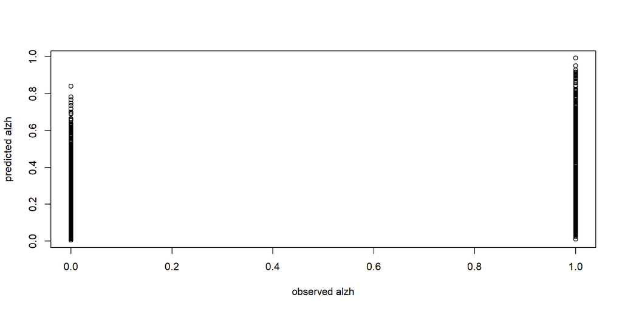

### Predicted vs $X$

```r
plot(alzheimer_data$hippo, predict(alzh.logistic, type="response"),
     xlab="hippo volume", ylab="predicted alzh")
```

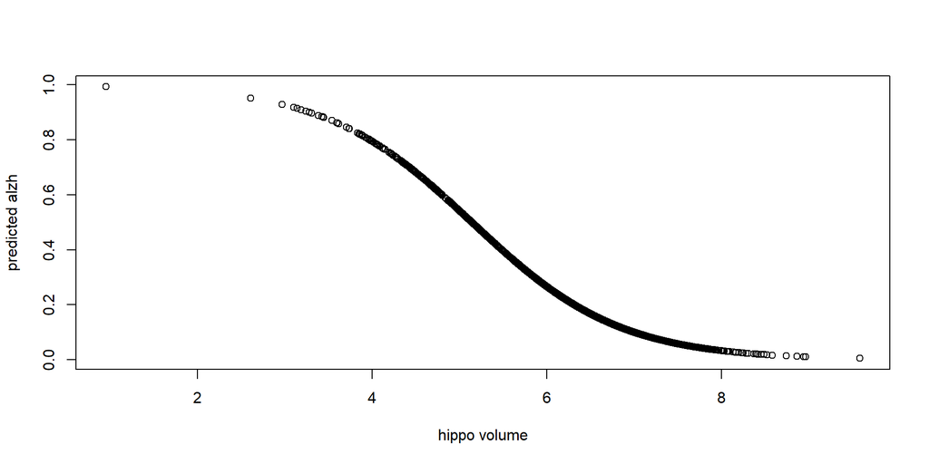

## Ex 5: Logistic Regression with Multiple Variables

- Similar to linear regression, we can include multiple explanatory variables in logistic regression.
- Connect $p$ (i.e., $P(Y=1)$) to a linear function of the predictors:
  $$log\frac{\hat p}{1-\hat p} = b_0 + b_1 \times x_{1} + … + b_p \times x_{p}$$

### Example

```r
alzh.glm.multi = glm(alzh ~ age + female + educ, family=binomial, data=alzheimer_data)
summary(alzh.glm.multi)$coefficients
```

```
               Estimate  Std. Error   z value     Pr(>|z|)
(Intercept) -2.02463880 0.455844285 -4.441514 8.932811e-06
age          0.04015417 0.005001781  8.027974 9.909571e-16
female1     -0.87341587 0.105761683 -8.258339 1.477131e-16
educ        -0.08759757 0.015192451 -5.765862 8.124175e-09
```

### Interpretation

- Consider the age variable. The estimated coefficient is 0.04015417. What information does it provide?
- The estimated log-odds AD is
  $$logit(\hat p_0) = b_0 + b_{age} age + b_2 female + b_3 educ$$
- Let $\hat p_1$ denote estimated log-odds after one year
  $$logit(\hat p_1) = b_0 + b_{age} (age+1) + b_2 female + b_3 educ$$

### Interpretation

- The estimated change in log-odds
  $$logit(\hat p_1) - logit(\hat p_0)=log\frac{\hat p_1}{1-\hat p_1} -log \frac{\hat p_0}{1-\hat p_0}=0.040154178$$
- Take exponential of both sides, we have
  $$\frac{\frac{\hat p_1}{1-\hat p_1}}{\frac{\hat p_0}{1-\hat p_0}} = exp(0.04015417)=104.1\%$$
- The new odds is 104.1% of the old odds, i.e., the odds of AD increase 104.1% -1 = 4.1% with one year increase in age.

### Interpretate Coefficients

- The odds of AD in one year later is $exp(0.04015417)=$ of the current odds.
- When holding gender and education fixed, the estimated increase in odds of AD in a year is $e^{0.04015417}-1=4.097\%$
- A 95% confidence interval is [3.08%, 5.12%].

```r
confint.default(alzh.glm.multi)[2,]
```

```
     2.5 %     97.5 %
0.03035086 0.04995748
```

```r
exp(confint.default(alzh.glm.multi)[2,])-1
```

```
     2.5 %     97.5 %
0.03081614 0.05122640
```

### Interpretate Coefficients

- What if we are interested in the increase in odds of AD in ten years (everything else is fixed)?
- The estimated increase in odds of AD in 10 years is
  $$e^{10*0.04015417}-1=49.4\%$$
- A $95\%$ C.I. for 10-year increase in odds: [35.5%, 64.8%].

```r
10*confint.default(alzh.glm.multi)[2,]
```

```
    2.5 %    97.5 %
0.3035086 0.4995748
```

```r
exp(10*confint.default(alzh.glm.multi)[2,])-1
```

```
    2.5 %    97.5 %
0.3546032 0.6480204
```

### Significance and P-value

- Lastly, let’s take a look at significance.
- All the three explanatory variables are significant.

```r
summary(alzh.glm.multi)$coefficients[-1,]
```

```
           Estimate  Std. Error   z value     Pr(>|z|)
age      0.04015417 0.005001781  8.027974 9.909571e-16
female1 -0.87341587 0.105761683 -8.258339 1.477131e-16
educ    -0.08759757 0.015192451 -5.765862 8.124175e-09
```